# Time Series Prediction of Swimming Pool Admissions

DA3 Assignment 3

Dominik Gulacsy

13/02/2021

[Github Repo](https://github.com/dgulacsy/da3-assignments/tree/main/da3-assignment3)

# Introduction

In this analytics exercise I used historical data on swimming pool admissions in the US city of Albuquerque to build a model that can be used to predict daily admission rates 12 months ahead.

# Data Cleaning & Wrangling

As a first step before the analysis I clean the data and add some features. The original data source that I use is a transaction data table which contains admissions into all of Albuquerque’s swimming pool. As my goal is to predict the admissions rate for all outdoor swimming pools I visited Albuquerque’s [Parks & Recreation Department’s site](https://www.cabq.gov/parksandrecreation/recreation/swimming/indoor-pools) to find out which location codes correspond to outdoor swimming pools. I discarded all admissions that were not belonging to any of these swimming pools. I aggregated the remaining observations to a daily level.

[figure not shown]

After looking at the data I decided to predict the sum of general admission types like child, teen, adult, senior, child pm etc. However there were some admission types which were also considerable like school-related or lesson-related admissions. I decided to use some of these other kind of admission rates to help give a better estimate for the general, paid admissions consisting of “ADMISTIER1” and “ADMISTIER2” categories.

# Feature Engineering

To predict the admission rates I had to extract some explanatory variables from the dates. Firstly I added the month week and day of the date as factor variables. Then I looked at the date whether it is weekend day or not, plus I also indicated by a factor variable which day of the week the date is. I also added holidays to capture the effect of increased free time to swimming pool ticket sales.

To use admission rates from other admission categories I created lagged variables and aggregated them to a weekly level to make them more robust.

# EDA

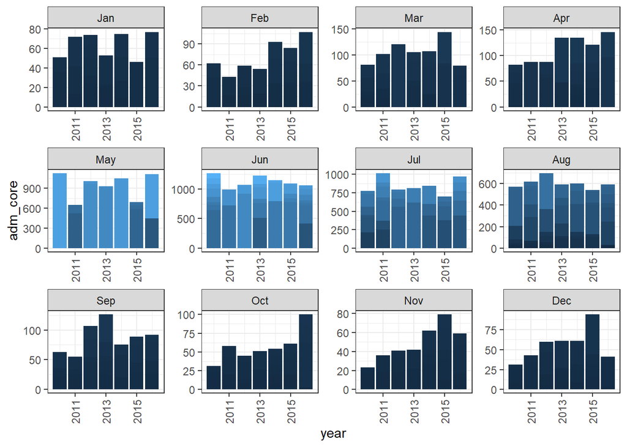

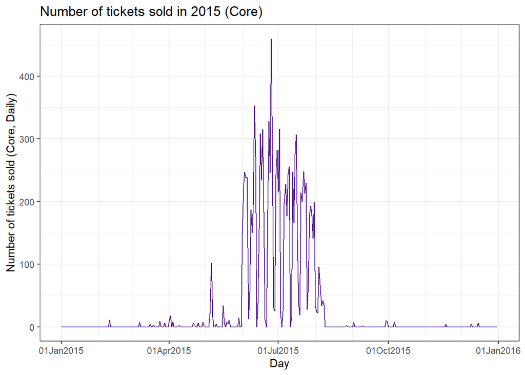

Based on the graphs we can see that ticket sales is not surprisingly is very high during the summer months and quite low in other months. It means that there is high seasonality in the data and it is vital to address this in the analysis. It can be also seen that even during the summer admissions fall to 0 some days which makes it quite clear that the swimming pools close for some days even in the summer season.

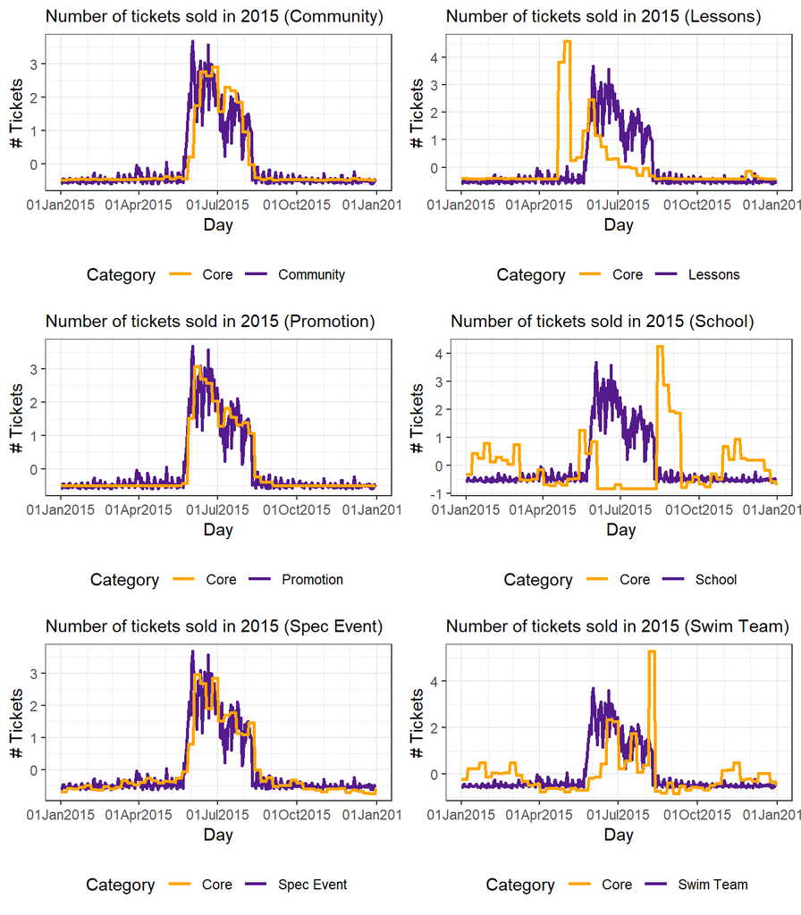

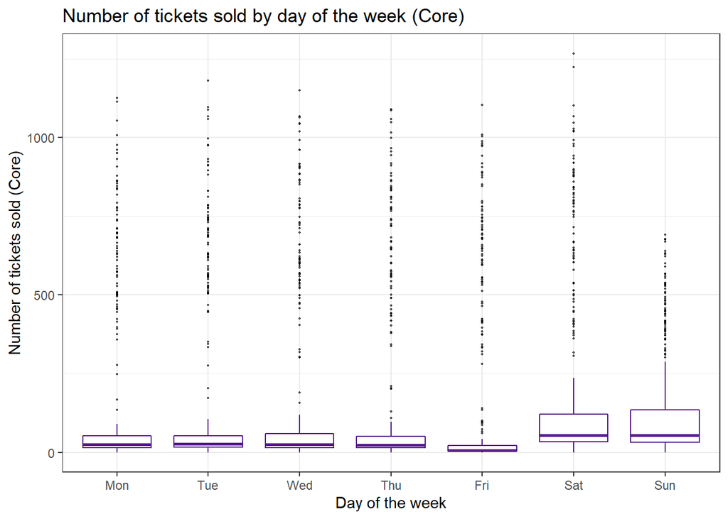

We can also see the pattern in the data that on the weekend generally more people visit the swimming pools.

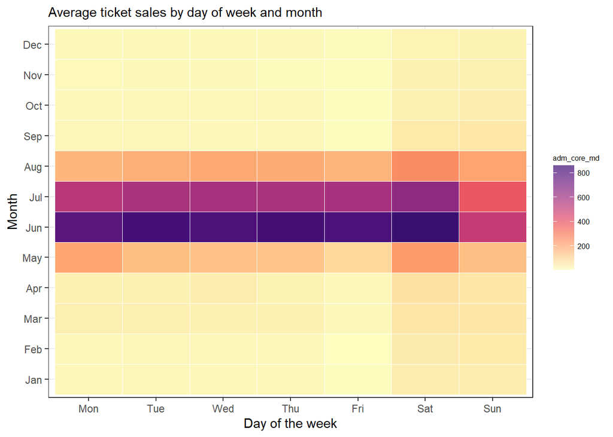

We can see a similar pattern on the heatmap, weekends are generally more popular, June is the busiest month followed by July and Sundays are relatively less busy in June than in other months. This helped greatly to decide what kind of interactions worth considering.

# Models

To make predictions I build three models. Each one is a multiple linear regression model. They are of increasing complexity. In the first regression I use only the trend, month and day of the week variables to make predictions. This serves as baseline model. Next I complement this model with the variable that captures holidays and I also include an interaction between the school period indicator variable and the day of week factor variable. Finally, I add the lagged admission rates and their interactions with months to arrive at the 3rd model.

|  | Test RMSE CV | Rel. Test RMSE CV |
| --- | --- | --- |
| reg1 | 124.28115 | 0.7734799 |
| reg2 | 113.22376 | 0.7046628 |
| reg3 | 87.94294 | 0.5473244 |

Looking at test set CV RMSEs the 3rd and most complex model performs the best. It has a much lower cross validated RMSE than the other two. Therefore I pick this model and take it to the holdout to test its usability on the live data. I do this by making predictions for days in 2016 which I separated from the training work set.

# Conclusion

Running the model on the holdout set I get a cross validated RMSE of 93.44 which is a bit higher than I got for the test sets. Overall, it seems sufficient however the acceptable range of RMSE is very much dependent on the business problem it is applied to. Using this model we would miss the actual general admission rate by 94 on average.

| Model | Holdout.RMSE | Rel..Holdout.RMSE |
| --- | --- | --- |
| reg3 | 93.44253 | 0.5815518 |

Based on the graphs we can also see that the model makes the largest errors by far in December. Errors are also large in May which is may be due to the instability in weather conditions and the fact that this is when the summer season kicks in and numbers quickly rise so there is a higher chance of making a huge error.

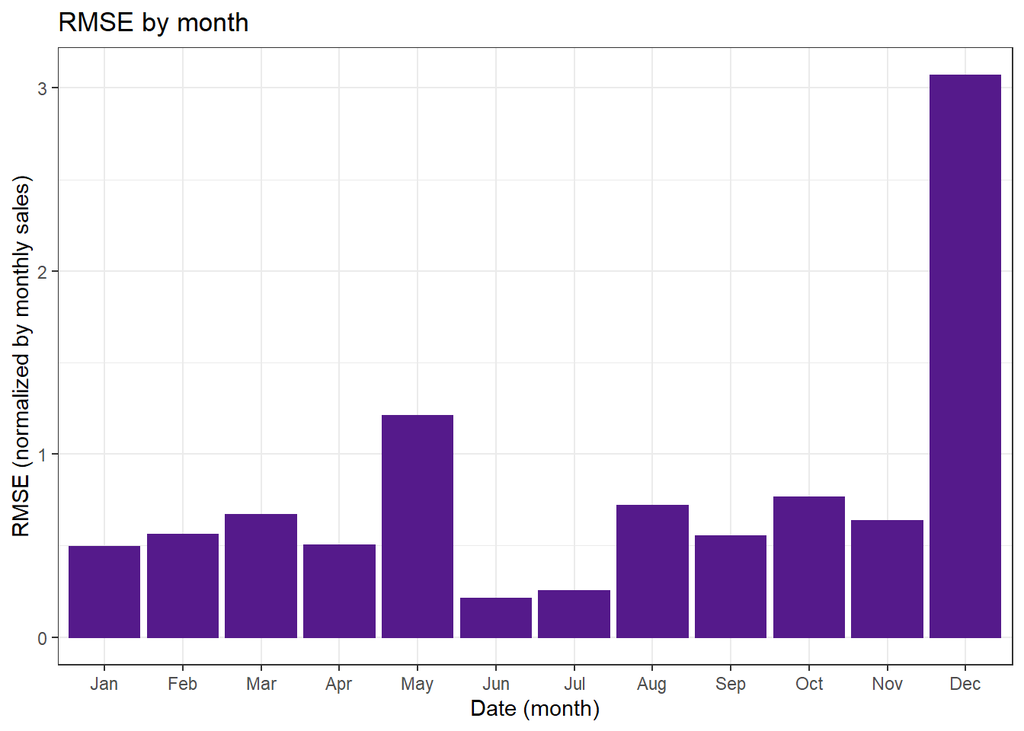

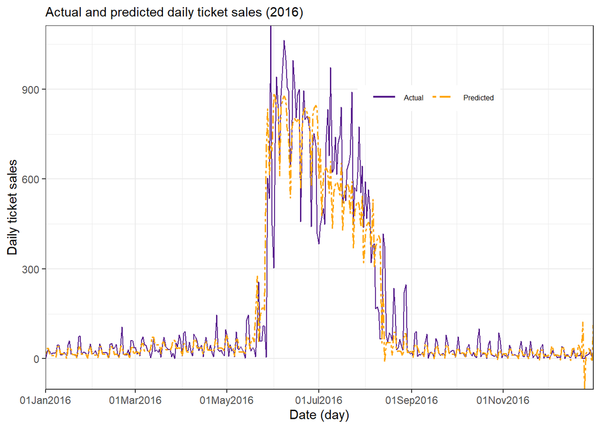